# Faceting with ggplot2

2024

## Faceting with ggplot2

- Faceting creates multiple plots based on the data’s subsets, allowing for easy comparisons.
- ggplot2 offers two main functions for faceting: `facet_wrap()` and `facet_grid()`.

## Why Use Faceting?

- Compare different subsets of your dataset within the same visual context.
- Identify patterns, trends, and outliers across groups more easily.

## The `facet_wrap()` Function

- `facet_wrap()` arranges plots in a specified number of rows or columns, wrapping around to create a compact layout.

```r
library(ggplot2)
ggplot(mpg, aes(x = displ, y = hwy)) +
  geom_point(aes(color = class)) +
  facet_wrap(~ class)
```

## The `facet_wrap()` Function

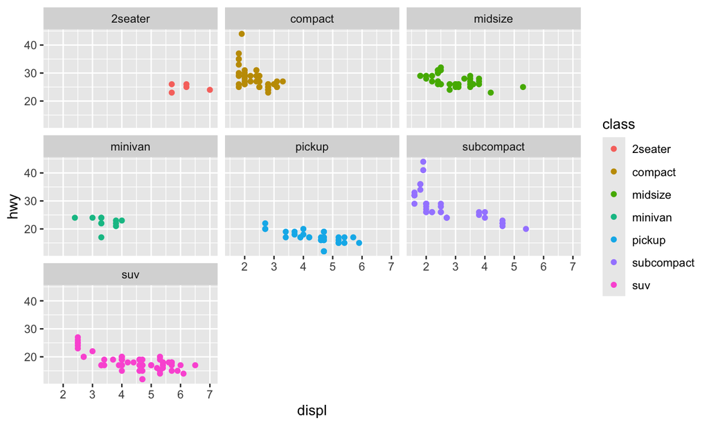

## Customizing `facet_wrap()`

- You can customize the layout with `nrow` or `ncol` and control the scales with `scales` argument.

```r
ggplot(mpg, aes(x = displ, y = hwy)) +
  geom_point(aes(color = class)) +
  facet_wrap(~ class, nrow = 2, scales = "free_y")
```

## Customizing `facet_wrap()`

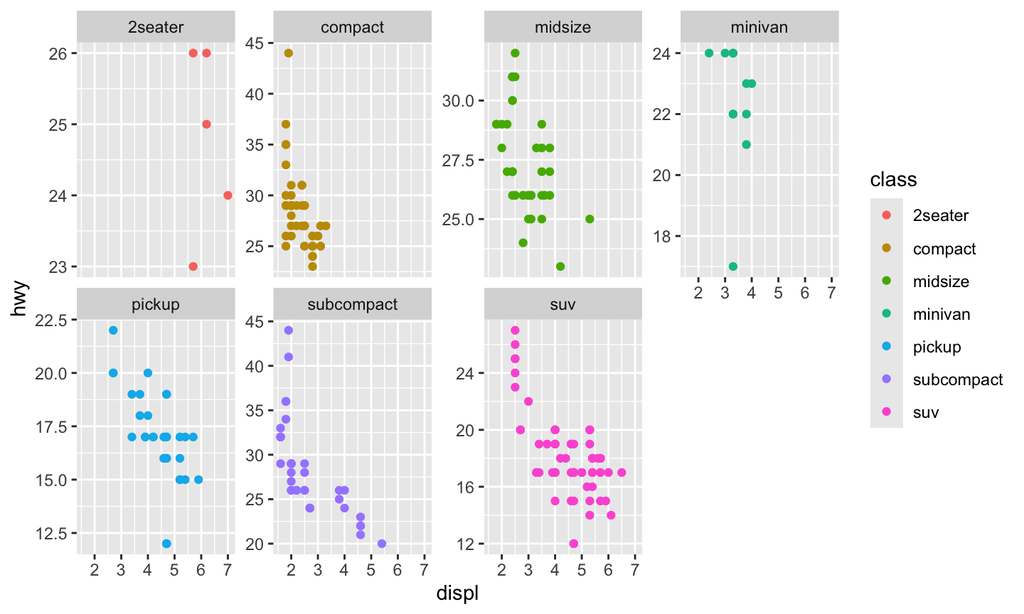

## The `facet_grid()` Function

- `facet_grid()` arranges plots in a grid based on the values of one or two variables.

```r
ggplot(mpg, aes(x = displ, y = hwy)) +
  geom_point(aes(color = class)) +
  facet_grid(rows = vars(drv), cols = vars(cyl))
```

## The `facet_grid()` Function

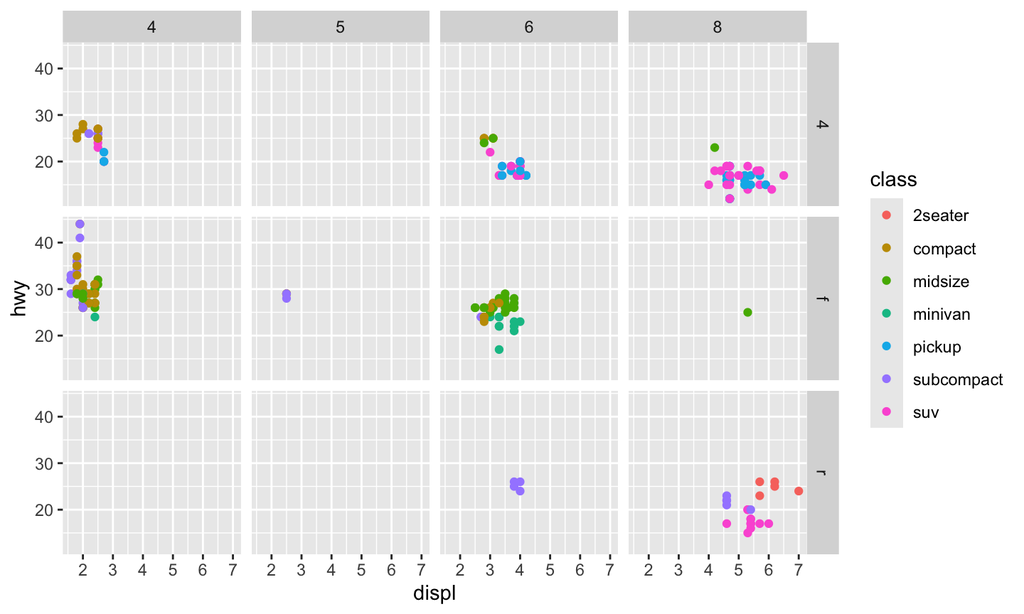

## Customizing `facet_grid()`

- Use the `scales` argument to control whether scales are shared across the grid and `space` to control the spacing of panels.

```r
ggplot(mpg, aes(x = displ, y = hwy)) +
  geom_point(aes(color = class)) +
  facet_grid(rows = vars(drv), cols = vars(cyl), scales = "free", space = "free")
```

## Customizing `facet_grid()`

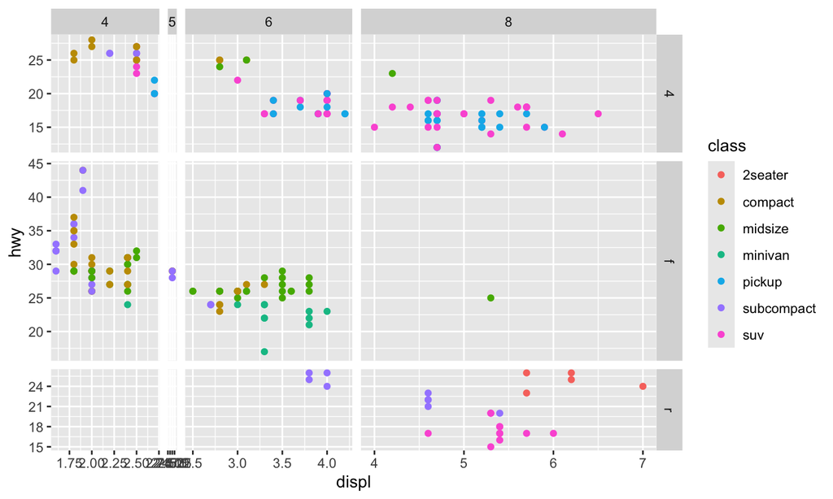

## Question

Use `facet_wrap()` to create individual scatter plots for each `class` of vehicle, showing the relationship between `displ` (engine displacement) and `hwy` (highway miles per gallon).

**Click here for the answer**

```r
ggplot(mpg, aes(x = displ, y = hwy)) +
  geom_point() +
  facet_wrap(~ class)
```

## Question

Modify the previous answer such that the scatter plots are organised into 3 rows with each plot using its own y-axis scale.

**Click here for the answer**

```r
ggplot(mpg, aes(x = displ, y = hwy)) +
  geom_point() +
  facet_wrap(~ class, nrow = 3, scales = "free_y")
```

## Question

Construct a ggplot2 command using `facet_grid()` to create a grid of plots by `drv` and `cyl`.

**Click here for the answer**

```r
ggplot(mpg, aes(x = displ, y = hwy)) +
  geom_point() +
  facet_grid(drv ~ cyl)
```

## Question

Modify the previous to allow each plot to have its own y-axis.

**Click here for the answer**

```r
ggplot(mpg, aes(x = displ, y = hwy)) +
  geom_point() +
  facet_grid(drv ~ cyl, scales = "free_y")
```